# Practical Machine Learning course project: Classification of human exercise quality

Ismay Pérez Sánchez

03/06/2015

This project has the aim of predicting using machine learning algorithms the quality of the exercises done by a set of humans monitored with multiple devices. This is inspired by the Human Activity Recognition [HAR](http://groupware.les.inf.puc-rio.br/har) group work. The task is to classify the parameters of each exercise observed in one of the following classes:

- A - exactly according to the specification.
- B - throwing the elbows to the front.
- C - lifting the dumbbell only halfway.
- D - lowering the dumbbell only halfway.
- E - throwing the hips to the front.

In the results it was found that as expected that *“”Random Forest* algorithm outperformed *“Decision Trees”* by a large margin (in this particular case, way better).

# Setting up and analysis on data input

The data provided by the course site is a subset or an out-of-date version of what you can find in the original site [here](http://groupware.les.inf.puc-rio.br/static/WLE/WearableComputing_weight_lifting_exercises_biceps_curl_variations.csv) (my guess is because the sum of the sizes of training and test set in coursera site differs from the original).

To improve the generation of this report I will build a function that check if file is already downloaded to avoid repeatedly download the same file (useful for those behind a proxy with low bandwidth)

```r
# this function simplify the work of download the input dataset
setup.filedata <- function(url) {
    url <- URLdecode(url)
    list <- strsplit( url, "/" )[[1]]
    filename <- list[ length(list) ]

    if ( ! file.exists( filename ) )
      download.file( url, filename )

    invisible()
}

setup.filedata("https://d396qusza40orc.cloudfront.net/predmachlearn/pml-training.csv")
```

Read and perform some initial analysis on data.

```r
input <- read.csv("pml-training.csv", na.strings = c("NA", "#DIV/0!"))
dimentions <- dim(input)
fnames <- names(input)
head(fnames, 10)
```

```
##  [1] "X"                    "user_name"            "raw_timestamp_part_1"
##  [4] "raw_timestamp_part_2" "cvtd_timestamp"       "new_window"
##  [7] "num_window"           "roll_belt"            "pitch_belt"
## [10] "yaw_belt"
```

The first 7 seven features seems to be irrelevant, as well as those with values almost unchanged and the ones with certain amount of NA values in their inputs (I don’t see how imputing values here could be a wise decision; perhaps with less features and a human expert opinion about the field that could decide if some of them are determinant no matter what then we could do some work, but it is not the case).

```r
# All this procedure is in a function because it will be handy to process the test set in the same way
stripped_unique_cols <- c()
stripped_na_cols <- c()

# remove
clean.data <- function(df, NAThreshold = 0.2) {
  # 1st step
  df <- df[, 8:ncol(df)]

  # 2nd step
  idx <- nearZeroVar(df)
  stripped_unique_cols <- fnames[idx]
  df <- df[, -idx]

  # 3rd step
  obs <- ncol(df)
  features <- nrow(df)
  naPercent <- apply(df, 2, function (x) { sum(is.na(x) / obs) })
  stripped_na_cols <- fnames[ naPercent >= NAThreshold ]
  df <- df[, naPercent < NAThreshold]

  df
}

training <- clean.data(input)
```

# Creation of training and test set.

Following the indications received in class, I choose to set a proportion of 3/2 between training and test set.

```r
init.seed <- function() {set.seed(12345)}

init.seed()
inTrain <- createDataPartition(y = training$classe, p = .6, list = FALSE)
training_set <- training[ inTrain, ]
testing_set <- training[ -inTrain, ]
```

# Machine learning algorithm analysis.

After some aditional research in this topic, I found [this site]http://www.dataschool.io/comparing-supervised-learning-algorithms/ where it is made a throughout analysis of machine learning algorithms with a fancy table with lot of parameters evaluated. From there we can verify that the best algorithms should be the last four, taking into account that they handle features interactions automatically and other characteristics. They are *Decision Trees*, *Random Forest*, *AdaBoost* and *Neural Networks*. Despite that “trees” do not handle very well irrelevant features (I already have stripped off 2/3 of all) I start with it because of the high training speed compared with the others.

## Decision trees.

```r
init.seed()
treeModel <- train(classe ~ ., data = training_set, method = "rpart")
treeModel
```

```
## CART
##
## 11776 samples
##    52 predictors
##     5 classes: 'A', 'B', 'C', 'D', 'E'
##
## No pre-processing
## Resampling: Bootstrapped (25 reps)
##
## Summary of sample sizes: 11776, 11776, 11776, 11776, 11776, 11776, ...
##
## Resampling results across tuning parameters:
##
##   cp          Accuracy   Kappa       Accuracy SD  Kappa SD
##   0.03909587  0.5013960  0.35074858  0.06575246   0.11060004
##   0.03946369  0.4988374  0.34682528  0.06482813   0.10893077
##   0.11449929  0.3333384  0.07372353  0.03986768   0.06147208
##
## Accuracy was used to select the optimal model using  the largest value.
## The final value used for the model was cp = 0.03909587.
```

Even in the training set the accuracy is remarkable poor as you can see in the model information.

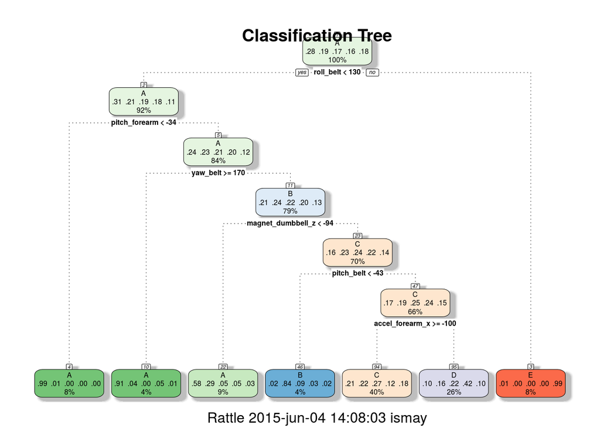

```r
fancyRpartPlot(treeModel$finalModel, uniform = T, main = "Classification Tree")
```

```r
# handy function to enhance my productivity
checkAccuracy <- function(model, dataset, show = TRUE) {
  pred <- predict(model, newdata = dataset)
  res <- confusionMatrix(dataset$classe, pred)
  if (show == TRUE) print(res)
  invisible(res)
}

t <- checkAccuracy(treeModel, testing_set)
```

```
## Confusion Matrix and Statistics
##
##           Reference
## Prediction    A    B    C    D    E
##          A 1357    3  693  171    8
##          B  229  259  725  305    0
##          C   38   28  819  483    0
##          D   66    8  389  823    0
##          E   15   10  557  200  660
##
## Overall Statistics
##
##                Accuracy : 0.4994
##                  95% CI : (0.4882, 0.5105)
##     No Information Rate : 0.4057
##     P-Value [Acc > NIR] : < 2.2e-16
##
##                   Kappa : 0.3764
##  Mcnemar's Test P-Value : < 2.2e-16
##
## Statistics by Class:
##
##                      Class: A Class: B Class: C Class: D Class: E
## Sensitivity            0.7959  0.84091   0.2573   0.4152  0.98802
## Specificity            0.8575  0.83298   0.8823   0.9210  0.89106
## Pos Pred Value         0.6080  0.17062   0.5987   0.6400  0.45770
## Neg Pred Value         0.9380  0.99226   0.6351   0.8233  0.99875
## Prevalence             0.2173  0.03926   0.4057   0.2526  0.08514
## Detection Rate         0.1730  0.03301   0.1044   0.1049  0.08412
## Detection Prevalence   0.2845  0.19347   0.1744   0.1639  0.18379
## Balanced Accuracy      0.8267  0.83694   0.5698   0.6681  0.93954
```

Now, we will check how far this model could be enhanced predicting all classes using preprocessing and cross validation.

```r
init.seed()
treeModelPPandCV <- train(classe ~ ., data = training_set, method = "rpart",
                          preProcess=c("center", "scale"),
                          trControl = trainControl(method = "cv", number = 4))

t2 <- checkAccuracy(treeModelPPandCV, testing_set)
```

```
## Confusion Matrix and Statistics
##
##           Reference
## Prediction    A    B    C    D    E
##          A 1357    3  693  171    8
##          B  229  259  725  305    0
##          C   38   28  819  483    0
##          D   66    8  389  823    0
##          E   15   10  557  200  660
##
## Overall Statistics
##
##                Accuracy : 0.4994
##                  95% CI : (0.4882, 0.5105)
##     No Information Rate : 0.4057
##     P-Value [Acc > NIR] : < 2.2e-16
##
##                   Kappa : 0.3764
##  Mcnemar's Test P-Value : < 2.2e-16
##
## Statistics by Class:
##
##                      Class: A Class: B Class: C Class: D Class: E
## Sensitivity            0.7959  0.84091   0.2573   0.4152  0.98802
## Specificity            0.8575  0.83298   0.8823   0.9210  0.89106
## Pos Pred Value         0.6080  0.17062   0.5987   0.6400  0.45770
## Neg Pred Value         0.9380  0.99226   0.6351   0.8233  0.99875
## Prevalence             0.2173  0.03926   0.4057   0.2526  0.08514
## Detection Rate         0.1730  0.03301   0.1044   0.1049  0.08412
## Detection Prevalence   0.2845  0.19347   0.1744   0.1639  0.18379
## Balanced Accuracy      0.8267  0.83694   0.5698   0.6681  0.93954
```

```r
# comparing predictions
sum(t$table == t2$table) == 25
```

```
## [1] TRUE
```

This model keep being as bad as the first one and the last check indicate that the model doesn’t change a bit and predict exactly in the same way, what could make us think that for *“Decision Trees”* there are some features needed that perhaps where left out, mainly some of the first 7 that were wipe out from the data set. But, as in every summary and note read in class or in internet the other cited algorithms perform better than these, I will move to next. Only in case of weird behaviour will be revisited the cleaning data process.

## Random Forest

The next method is *“Random Forest”*. As no improvement was seen doing cross validation and preprocessing we will go without any improvement first.

```r
init.seed()
rfModel <- train(classe ~ ., data = training_set, method = "rf")

rfResult <- checkAccuracy(rfModel, testing_set)
```

```
## Confusion Matrix and Statistics
##
##           Reference
## Prediction    A    B    C    D    E
##          A 2228    4    0    0    0
##          B   12 1500    6    0    0
##          C    0    6 1357    5    0
##          D    0    0   18 1266    2
##          E    0    1    3    5 1433
##
## Overall Statistics
##
##                Accuracy : 0.9921
##                  95% CI : (0.9899, 0.9939)
##     No Information Rate : 0.2855
##     P-Value [Acc > NIR] : < 2.2e-16
##
##                   Kappa : 0.99
##  Mcnemar's Test P-Value : NA
##
## Statistics by Class:
##
##                      Class: A Class: B Class: C Class: D Class: E
## Sensitivity            0.9946   0.9927   0.9805   0.9922   0.9986
## Specificity            0.9993   0.9972   0.9983   0.9970   0.9986
## Pos Pred Value         0.9982   0.9881   0.9920   0.9844   0.9938
## Neg Pred Value         0.9979   0.9983   0.9958   0.9985   0.9997
## Prevalence             0.2855   0.1926   0.1764   0.1626   0.1829
## Detection Rate         0.2840   0.1912   0.1730   0.1614   0.1826
## Detection Prevalence   0.2845   0.1935   0.1744   0.1639   0.1838
## Balanced Accuracy      0.9970   0.9949   0.9894   0.9946   0.9986
```

```r
init.seed()
rf2Model <- train(classe ~ ., data = training_set, method = "rf",
                 trControl = trainControl(method = "cv", number = 4))

rf2Result <- checkAccuracy(rf2Model, testing_set)
```

```
## Confusion Matrix and Statistics
##
##           Reference
## Prediction    A    B    C    D    E
##          A 2226    6    0    0    0
##          B    9 1503    6    0    0
##          C    0    7 1358    3    0
##          D    0    0   19 1265    2
##          E    0    1    3    5 1433
##
## Overall Statistics
##
##                Accuracy : 0.9922
##                  95% CI : (0.99, 0.994)
##     No Information Rate : 0.2849
##     P-Value [Acc > NIR] : < 2.2e-16
##
##                   Kappa : 0.9902
##  Mcnemar's Test P-Value : NA
##
## Statistics by Class:
##
##                      Class: A Class: B Class: C Class: D Class: E
## Sensitivity            0.9960   0.9908   0.9798   0.9937   0.9986
## Specificity            0.9989   0.9976   0.9985   0.9968   0.9986
## Pos Pred Value         0.9973   0.9901   0.9927   0.9837   0.9938
## Neg Pred Value         0.9984   0.9978   0.9957   0.9988   0.9997
## Prevalence             0.2849   0.1933   0.1767   0.1622   0.1829
## Detection Rate         0.2837   0.1916   0.1731   0.1612   0.1826
## Detection Prevalence   0.2845   0.1935   0.1744   0.1639   0.1838
## Balanced Accuracy      0.9975   0.9942   0.9891   0.9953   0.9986
```

# Prediction

Taking the best model available, this code predict the outcome of the intended test data for submission and generate the solutions into separate files ready to submit (the file generation code was taking from the assignment page).

```r
setup.filedata("https://d396qusza40orc.cloudfront.net/predmachlearn/pml-testing.csv")
input2 <- read.csv("pml-testing.csv", na.strings = c("NA", "#DIV/0!"))
testing <- clean.data(input2)

result <- predict(rf2Model, newdata = testing)

pml_write_files = function(x){
  n = length(x)
  for(i in 1:n){
    filename = paste0("problem_id_",i,".txt")
    write.table(x[i], file = filename, quote = FALSE, row.names = FALSE, col.names = FALSE)
  }
}

pml_write_files(result)
```

The result was 20 successes out of 20, something highly expected with the level of accuracy of the models analysed and only 20 observations to predict. Fair to say that with the difference between *Random Forest* models the result would be the same with either of them.

# In and out of sample error

The out of sample error was already calculated, now let see the error predicting the training (in sample error).

```r
checkAccuracy(rfModel, training_set)
```

```
## Confusion Matrix and Statistics
##
##           Reference
## Prediction    A    B    C    D    E
##          A 3348    0    0    0    0
##          B    0 2279    0    0    0
##          C    0    0 2054    0    0
##          D    0    0    0 1930    0
##          E    0    0    0    0 2165
##
## Overall Statistics
##
##                Accuracy : 1
##                  95% CI : (0.9997, 1)
##     No Information Rate : 0.2843
##     P-Value [Acc > NIR] : < 2.2e-16
##
##                   Kappa : 1
##  Mcnemar's Test P-Value : NA
##
## Statistics by Class:
##
##                      Class: A Class: B Class: C Class: D Class: E
## Sensitivity            1.0000   1.0000   1.0000   1.0000   1.0000
## Specificity            1.0000   1.0000   1.0000   1.0000   1.0000
## Pos Pred Value         1.0000   1.0000   1.0000   1.0000   1.0000
## Neg Pred Value         1.0000   1.0000   1.0000   1.0000   1.0000
## Prevalence             0.2843   0.1935   0.1744   0.1639   0.1838
## Detection Rate         0.2843   0.1935   0.1744   0.1639   0.1838
## Detection Prevalence   0.2843   0.1935   0.1744   0.1639   0.1838
## Balanced Accuracy      1.0000   1.0000   1.0000   1.0000   1.0000
```

```r
checkAccuracy(rf2Model, training_set)
```

```
## Confusion Matrix and Statistics
##
##           Reference
## Prediction    A    B    C    D    E
##          A 3348    0    0    0    0
##          B    0 2279    0    0    0
##          C    0    0 2054    0    0
##          D    0    0    0 1930    0
##          E    0    0    0    0 2165
##
## Overall Statistics
##
##                Accuracy : 1
##                  95% CI : (0.9997, 1)
##     No Information Rate : 0.2843
##     P-Value [Acc > NIR] : < 2.2e-16
##
##                   Kappa : 1
##  Mcnemar's Test P-Value : NA
##
## Statistics by Class:
##
##                      Class: A Class: B Class: C Class: D Class: E
## Sensitivity            1.0000   1.0000   1.0000   1.0000   1.0000
## Specificity            1.0000   1.0000   1.0000   1.0000   1.0000
## Pos Pred Value         1.0000   1.0000   1.0000   1.0000   1.0000
## Neg Pred Value         1.0000   1.0000   1.0000   1.0000   1.0000
## Prevalence             0.2843   0.1935   0.1744   0.1639   0.1838
## Detection Rate         0.2843   0.1935   0.1744   0.1639   0.1838
## Detection Prevalence   0.2843   0.1935   0.1744   0.1639   0.1838
## Balanced Accuracy      1.0000   1.0000   1.0000   1.0000   1.0000
```

We can see, the *Random Forest* models are probably over fitted. They performed pretty well when predicted the testing subset but this is a sign that something could be improved in the feature selection (it was already noted with *Decision Trees*). Thus, we perhaps could obtain a non so perfect fitted model respect the training subset and an even better accuracy against the testing subset.

A real analysis should include others models like the ones mentioned at the beginning, even, it could be tested regression models creating a dummy variable from the outcome. Making a decision comparing more candidates should be a preferred choise in a real predicting tool, the names can be found this way `names(getModelInfo())`.  
Remember that this analysis is “biased” by the purpose of accuratly predict the 20 values that must be submitted, not to create an industrial level prediction tool.